# Informe de Análisis Descriptivo de Datos EmpresaB&C

Paula Andrea López Arango

2023-08-10

# Introducción

Este informe presenta el análisis descriptivo de la base de datos “vivienda_faltantes”, propiedad de la empresa B&C. Para llevar a cabo este estudio se empleó software R, herramienta estadística líder en el ámbito del análisis de datos. El proyecto se enfoca en tres fases, la primera comprende un preprocesamiento y organización de la data, como preparación para el análisis posterior. En la segunda fase, se realiza un análisis univariado, explorando las variables individualmente para entender su distribución y características principales. Finalmente, en la tercera etapa se realiza cruce de variables con el objetivo de identificar tendencias y patrones en los datos que pueden ser de ayuda en la toma de decisiones de la empresa B&C.

# Objetivos

1. Realizar análisis descriptivo de datos.
2. Identificar las características de las viviendas más vendidas en Cali.
3. Identificar la zona de mayor popularidad y posible desarrollo.
4. Identificar las áreas con mayor nivel socioeconómico.
5. Identificar patrones en los datos que puedan ser relevante para empresa B&C.

# Métodos

El análisis de datos se realizó en 3 fases:

**Fase I. Pre procesamiento de data:** cargue de información, revisión, descripción de tipo de data, estandarización y visualización de variables.

**Fase II. Análisis univariado de las variables:**

- Cálculo de indicadores de centro: media, mediana, media truncada
- Cálculo de indicadores de dispersión: rango, desviación estándar, desviación absoluta
- Cálculo de indicadores de forma: curtosis, asimetría
- Cálculo de Indicador de posición: cuartiles
- Visualización grafica de indicadores

**Fase III. Cruce de variables**: identificación de tendencia e información relevante para la compañía.

# Resultados

### Fase I. Pre procesamiento de data

La base de datos “vivienda_faltantes” está compuesta por 8330 datos y 13 variables.

```
##  [1] "id"        "zona"      "piso"      "estrato"   "preciom"   "areaconst"
##  [7] "parquea"   "banios"    "habitac"   "tipo"      "barrio"    "longitud"
## [13] "latitud"
```

Hay 4279 datos en valor NA siendo las variables piso y parqueadero con mayor número de datos faltantes.

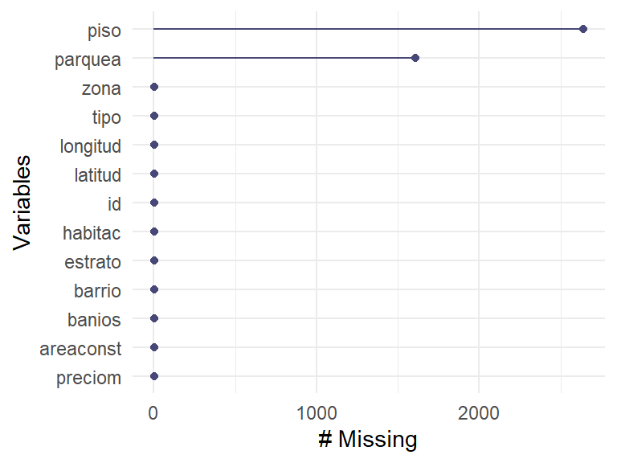

```
##        id      zona      piso   estrato   preciom areaconst   parquea    banios
##         3         3      2641         3         2         3      1606         3
##   habitac      tipo    barrio  longitud   latitud
##         3         3         3         3         3
```

Las variables presentan las siguientes subdivisiones:

```
## $Uzona
## [1] "Zona Oeste"   "Zona Sur"     "Zona Norte"   "Zona Oriente" "Zona Centro"
## [6] NA
##
## $Upiso
##  [1]  4  1 NA  2  6  8  3  9  5 12 11  7 10
##
## $Uestrato
## [1]  6  5  3  4 NA
##
## $Uparquead
##  [1]  2  1  4  8 NA  3  6  5 10  7  9
##
## $Ubanios
##  [1]  4  7  2 10  3  5  1  6  0  8  9 NA
##
## $Utipo
## [1] "Apartamento" "Casa"        "APARTAMENTO" "casa"        "CASA"
## [6] "apto"        NA
```

La variable tipo requirió estandarización para corregir errores de escritura.

```
## [1] "apartamento" "casa"        NA
```

### Visualización de variables

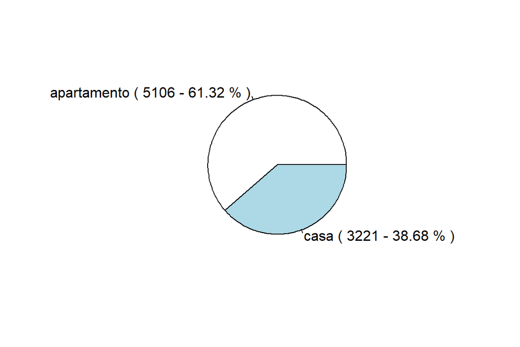

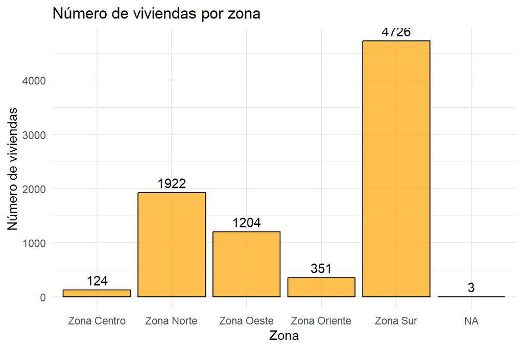

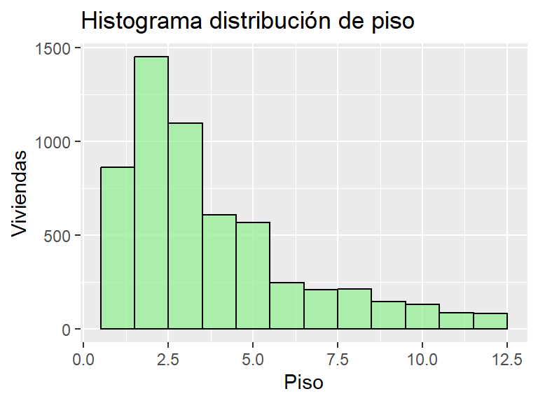

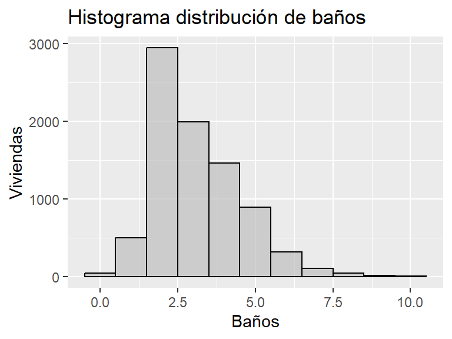

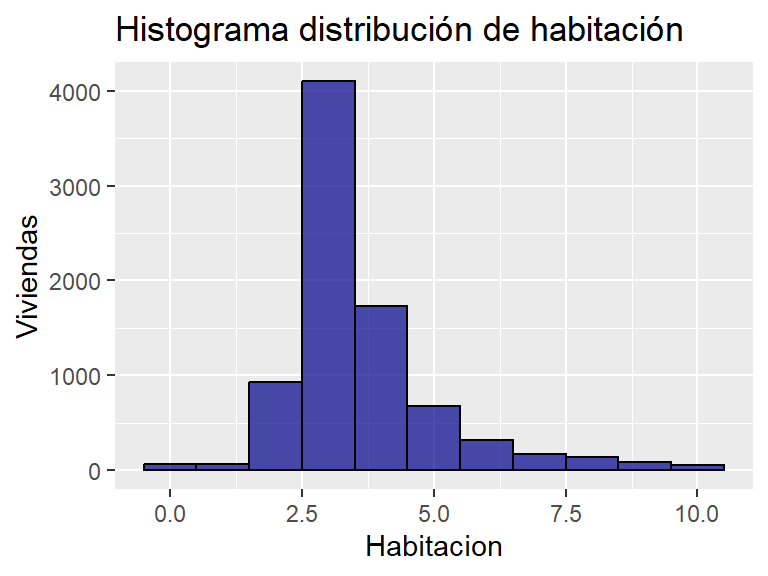

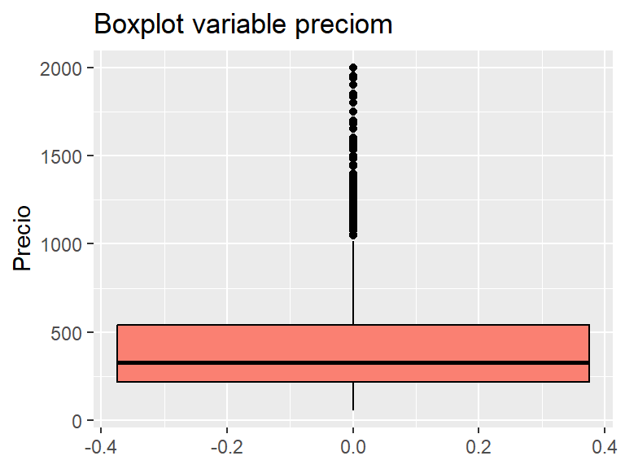

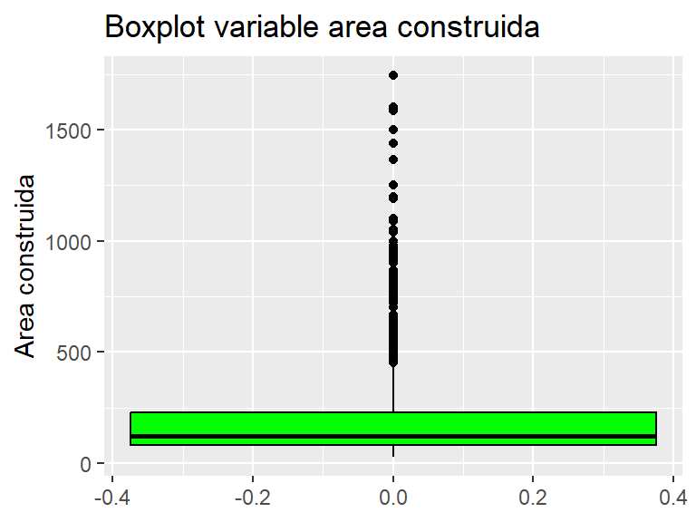

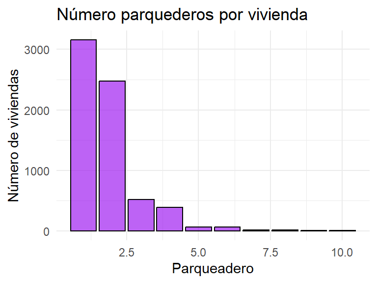

### **Fase II. Analisis univariado de varaible**

Para las variables numéricas: piso, estrato, preciom, areaconst, parquea, banios, habitac, se calculan:

- Indicadores de centro: media, mediana, media truncada
- Indicadores de dispersión: rango, desviación estándar, desviación absoluta
- Indicadores de forma: curtosis, asimetría.

```
## $piso
##    vars    n mean   sd median trimmed  mad min max range skew kurtosis   se
## X1    1 5689 3.77 2.62      3    3.37 1.48   1  12    11 1.28     1.05 0.03
##
## $estrato
##    vars    n mean   sd median trimmed  mad min max range  skew kurtosis   se
## X1    1 8327 4.63 1.03      5    4.67 1.48   3   6     3 -0.18    -1.11 0.01
##
## $preciom
##    vars    n   mean     sd median trimmed    mad min  max range skew kurtosis
## X1    1 8328 434.24 329.02    330  374.72 209.05  58 1999  1941 1.85     3.66
##      se
## X1 3.61
##
## $areaconst
##    vars    n   mean     sd median trimmed   mad min  max range skew kurtosis
## X1    1 8327 174.99 142.95    123  149.22 84.51  30 1745  1715 2.69     12.9
##      se
## X1 1.57
##
## $parquea
##    vars    n mean   sd median trimmed  mad min max range skew kurtosis   se
## X1    1 6724 1.84 1.13      2    1.62 1.48   1  10     9 2.32     8.29 0.01
##
## $banios
##    vars    n mean   sd median trimmed  mad min max range skew kurtosis   se
## X1    1 8327 3.11 1.43      3    2.99 1.48   0  10    10 0.92     1.12 0.02
##
## $habitac
##    vars    n mean   sd median trimmed  mad min max range skew kurtosis   se
## X1    1 8327 3.61 1.46      3    3.41 1.48   0  10    10 1.64     3.99 0.02
```

- Indicador de posición: caurtiles

```
## $piso
## 25% 50% 75%
##   2   3   5
##
## $estrato
## 25% 50% 75%
##   4   5   5
##
## $preciom
## 25% 50% 75%
## 220 330 540
##
## $areaconst
## 25% 50% 75%
##  80 123 229
##
## $parquea
## 25% 50% 75%
##   1   2   2
##
## $banios
## 25% 50% 75%
##   2   3   4
##
## $habitac
## 25% 50% 75%
##   3   3   4
```

Comentarios sobre los restultados del calculo de indicadores.

**“piso”**

- La distribución es asimétrica hacia la derecha (skew = 1.28), indicando que hay algunas viviendas con un número muy alto de pisos.

**“estrato”**

- El estrato medio es de 4.63, la mediana de 5, la distribución tiene una leve asimetría negativa (skew = -0.18), lo que confirma que hay más datos agrupados en los estratos superiores.

**“preciom”**

- Posee una desviación estandar alta (329.02) para el precio medio es de 434.24.
- La mediana es de 330, lo que indica que el 50% de las viviendas tienen un precio inferior a 330.
- La distribución es asimétrica hacia la derecha (skew = 1.85), lo que sugiere que hay algunas viviendas con precios muy altos que elevan la media.

**“areaconst”**

- El área media de construcción es de 174.99, con una desviación estándar de 142.95.
- La distribución es fuertemente asimétrica hacia la derecha (skew = 2.69), lo que sugiere que hay algunas viviendas con áreas de construcción muy grandes.
- La curtosis es alta, lo que indica una distribución con extremos.

**“parquea”**

**“habitac”**

- La distribución es asimétrica hacia la derecha, lo que sugiere que hay algunas viviendas con un número muy alto de habitaciones.

### **Fase III. Cruce de variables**:

```
## # A tibble: 3 × 2
##   tipo        mean_price
##   <chr>            <dbl>
## 1 casa              540.
## 2 apartamento       368.
## 3 <NA>              330
```

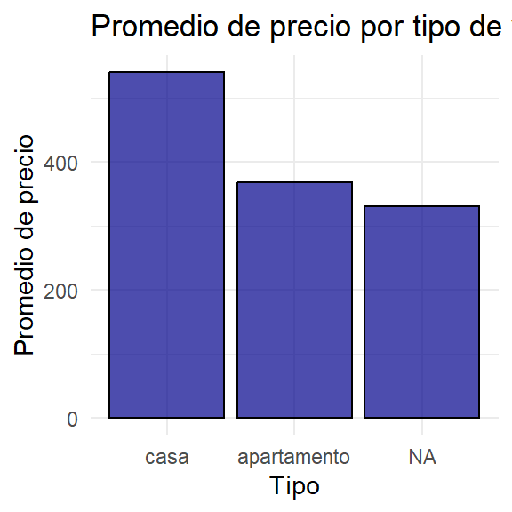

```
## # A tibble: 3 × 2
##   tipo        mean_areaconst
##   <chr>                <dbl>
## 1 casa                  273.
## 2 apartamento           113.
## 3 <NA>                  NaN
```

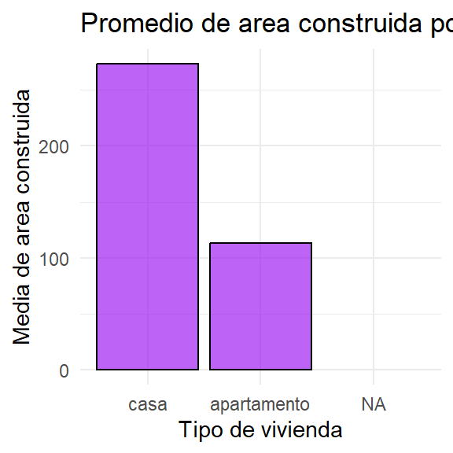

```
## # A tibble: 6 × 2
##   zona         mean_price
##   <chr>             <dbl>
## 1 Zona Oeste         679.
## 2 Zona Sur           427.
## 3 Zona Norte         346.
## 4 <NA>               330
## 5 Zona Centro        310.
## 6 Zona Oriente       229.
```

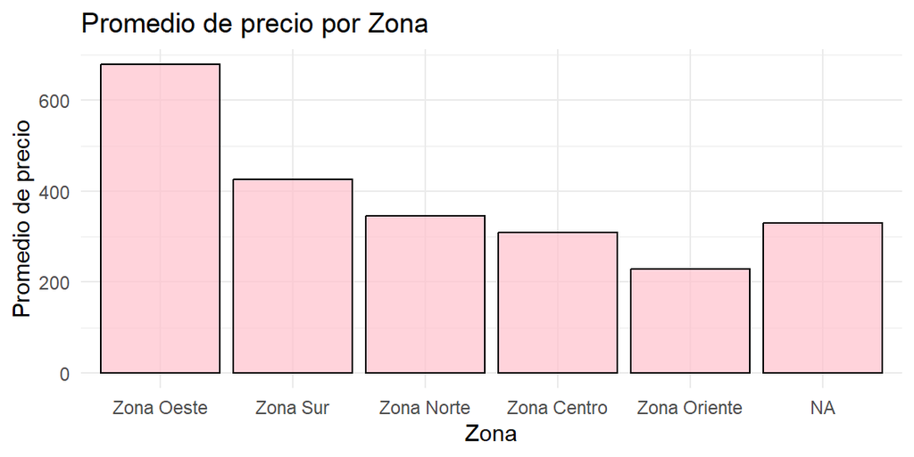

```
## # A tibble: 6 × 2
##   zona         median_estrato
##   <chr>                 <dbl>
## 1 Zona Oeste                6
## 2 Zona Sur                  5
## 3 Zona Norte                4
## 4 Zona Centro               3
## 5 Zona Oriente              3
## 6 <NA>                     NA
```

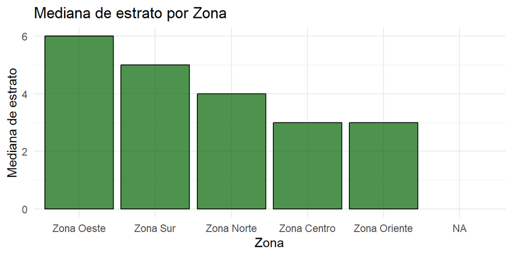

#### Cruces calculados pero no graficados

```
## # A tibble: 5 × 2
##   estrato mean_price
##     <dbl>      <dbl>
## 1       6       801.
## 2       5       410.
## 3      NA       330
## 4       4       275.
## 5       3       210.
```

```
## # A tibble: 6 × 2
##   zona         mean_areaconst
##   <chr>                 <dbl>
## 1 Zona Oeste             197.
## 2 Zona Centro            194.
## 3 Zona Oriente           192.
## 4 Zona Sur               173.
## 5 Zona Norte             161.
## 6 <NA>                   NaN
```

```
## # A tibble: 5 × 2
##   estrato mean_areaconst
##     <dbl>          <dbl>
## 1       6           248.
## 2       5           173.
## 3       3           142.
## 4       4           131.
## 5      NA           NaN
```